# 10: Exploring figures

Feed composition and temperature shape nutrient pressures across global salmon aquaculture locations

Author

Tormey Reimer

Published

5 August 2026

← Previous: Data analysis

Next: Figures for manuscript →

# 1 Overview

This script explores various ways that data from the experiments/model simulations might be visualised. Not all of these figures made it to the final manuscript.

# 2 Get data

**Get locations of farms for mapping**

```r
farm_locs <- file.path(input_farm_coords_path, "farm_static_data.qs") %>%
  qread() %>%
  rename(farm_ID = farm_id) %>%
  mutate(
    longitude = st_coordinates(geometry)[, 1],
    latitude = st_coordinates(geometry)[, 2]
  ) %>%
  mutate(
    country = as.factor(country),
    region = case_when(
      country %in% c("Canada", "United States of America") & longitude < -100 ~ "North America (WC)",
      country %in% c("Canada", "United States of America") & longitude < -50 ~ "North America (EC)",
      country %in% c("Ireland", "United Kingdom") ~ "UK & Ireland",
      country %in% c("Iceland", "Faroe Islands") ~ "Iceland & FI",
      country %in% c("Norway", "Finland") ~ "Scandinavia",
      country == "Australia" ~ "Australia",
      country == "Chile" ~ "Chile",
      country == "Russian Federation" ~ NA
    ) %>% as.factor()
  )

farm_temps <- file.path(input_farm_coords_path, ("farm_temporal_data.qs")) %>%
  qread() %>%
  rename(farm_ID = farm_id) %>%
  group_by(farm_ID) %>%
  reframe(mean_temp = mean(temp_c))

farm_locs <- farm_locs %>%
  left_join(farm_temps, by = join_by(farm_ID))
```

The total values describe selected output variables (measures) summed over the entire period of a salmon growing period (548 days). The data were generated from a suite of model runs which cover several dimensions:

- 2750 unique farms
- 3 different feed groups, representing different formulations of salmon feed: MD (marine-dominant), AD (animal-dominant) and PD (plant-dominant)
- 3 different feed types representing levels of digestibility of each of the three different feeds: mean digestibility, minimum digestibility, and maximum digestibility

**Get farm ends data**

```r
clean_up <- function(df) {
  df %>%
  convert_feeds_to_levels() %>%
  mutate(
    feed = factor(
      feed,
      levels = c("marine_dominant_biomar", "plant_dominant_biomar", "animal_dominant_biomar"),
      labels = c("MD", "PD", "AD")
    ),
    mean_value_perbiom = mean_value_perbiom %>% set_units("g g_fish-1") %>% set_units("kg t_fish-1"),
    sd_per_biom = sd_per_biom %>% set_units("g g_fish-1") %>% set_units("kg t_fish-1"),
    mean_value = mean_value %>% set_units("g") %>% set_units("kg"),
    sd_value = sd_value %>% set_units("g") %>% set_units("kg")
  )
}

farm_ends_carbon <- file.path(output_path, "model_run_outputs", "farm_ends_total_carbon.qs") %>%
  qread() %>% clean_up() %>%
  mutate(nutrient = as.factor("C")) %>%
  select(-mean_value, -sd_value)

farm_ends_carbon_uneat <- file.path(output_path, "model_run_outputs", "farm_ends_carbon_uneat.qs") %>%
  qread() %>% clean_up() %>%
  mutate(nutrient = as.factor("C")) %>%
  select(-mean_value, -sd_value)

farm_ends_carbon_excr <- file.path(output_path, "model_run_outputs", "farm_ends_carbon_excr.qs") %>%
  qread() %>% clean_up() %>%
  mutate(nutrient = as.factor("C")) %>%
  select(-mean_value, -sd_value)


farm_ends_nitrogen <- file.path(output_path, "model_run_outputs", "farm_ends_total_nitrogen.qs") %>%
  qread() %>% clean_up() %>%
  mutate(nutrient = as.factor("N")) %>%
  select(-mean_value, -sd_value)

farm_ends_nitrogen_uneat <- file.path(output_path, "model_run_outputs", "farm_ends_nitrogen_uneat.qs") %>%
  qread() %>% clean_up() %>%
  mutate(nutrient = as.factor("N")) %>%
  select(-mean_value, -sd_value)

farm_ends_nitrogen_excr <- file.path(output_path, "model_run_outputs", "farm_ends_nitrogen_excr.qs") %>%
  qread() %>% clean_up() %>%
  mutate(nutrient = as.factor("N")) %>%
  select(-mean_value, -sd_value)

farm_ends_weight <- file.path(output_path, "model_run_outputs", "farm_ends_weight.qs") %>%
  qread() %>% clean_up() %>%
  select(-mean_value_perbiom, -sd_per_biom)


# These come from the data analysis script
farm_ends_carbon_2 <- qread(file.path(data_analysis_path, "farm_ends_carbon.qs"))
farm_ends_nitrogen_2 <- qread(file.path(data_analysis_path, "farm_ends_nitrogen.qs"))

coefs_nitrogen <- qread(file.path(data_analysis_path, "coefs_nitrogen.qs"))
coefs_carbon <- qread(file.path(data_analysis_path, "coefs_carbon.qs"))
```

# 3 Main text figures

## 3.1 Total C and N to environment

**Prepare combined C and N data for plotting**

```r
farm_ends_CN <- rbind(farm_ends_carbon, farm_ends_nitrogen) %>%
  mutate(
    feed_level = factor(
      feed_level,
      levels = c("min", "mean", "max"),
      labels = c("Minimum", "Mean", "Maximum"))
  )

nutrient_labels <- data.frame(
  nutrient = levels(farm_ends_CN$nutrient),
  label = c("Carbon", "Nitrogen")
)
```

**Plot total C and N loading to environment by feed and digestibility**

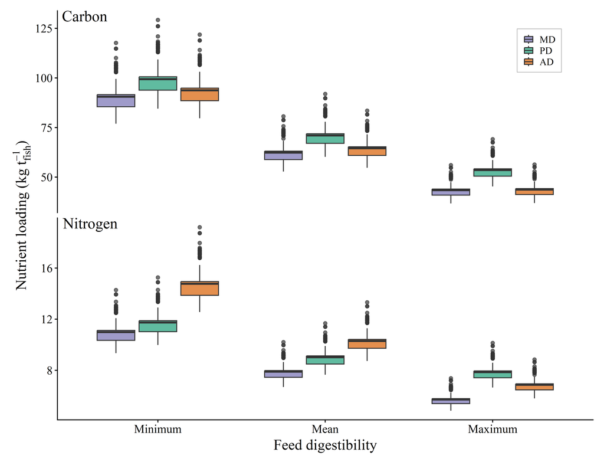

Figure 1: Total carbon (top) and nitrogen (bbottom) loading to the environment with different feeds and digestibility levels.

```r
p1 <- farm_ends_CN %>%
  ggplot(aes(x = feed_level, y = drop_units(mean_value_perbiom), fill = feed)) +
  geom_boxplot(alpha = 0.7) +
  scale_fill_manual(values = feed_pal) +
  facet_grid(
    rows = vars(nutrient),
    scales = "free"
  ) +
  geom_text(
    data = nutrient_labels,
    aes(x = -Inf, y = Inf, label = label),
    hjust = -0.1, vjust = 1,
    size = 5.5, family = "serif",
    inherit.aes = FALSE
  ) +
  labs(
    x = "Feed digestibility",
    y = expression("Nutrient loading (kg"~t[fish]^{-1}*")")
  ) +
  prettyplot_600() +
  theme(
    legend.position = "none",
    strip.text = element_blank(),
    strip.background = element_blank()
  )

legend_grob <- ggpubr::get_legend(
  p1 +
    guides(colour = guide_legend(ncol = 1)) +
    theme(
      legend.position = "right",
      legend.background = element_rect(fill = "white", colour = "grey70", linewidth = 0.3),
      legend.margin     = margin(5, 6, 5, 6),
      legend.key.size   = unit(0.4, "cm"),
      legend.text       = element_text(size = 10),
      legend.title      = element_blank()
    )
)

p1 + inset_element(
  legend_grob,
  left   = 0.85, right  = 0.95,  # x start, x end (fraction of plot width)
  bottom = 0.85, top    = 0.95,   # y start, y end
  align_to = "full"  # relative to full plot, not just panel area
)
```

## 3.2 Global loading of C and N

**Prepare global C and N loading data for mapping**

```r
global_data <- rbind(farm_ends_carbon, farm_ends_nitrogen) %>%
  merge(farm_locs, by = "farm_ID") %>%
  st_as_sf(crs = 4326) %>%
  st_transform(crs = "+proj=robin") %>%
  select(farm_ID, feed, measure, mean_value_perbiom, nutrient, feed_level, country)

Cr <- range(global_data$mean_value_perbiom[global_data$nutrient == "C"])
Nr <- range(global_data$mean_value_perbiom[global_data$nutrient == "N"])

print(
  sprintf("Range of C: %f - %f Mt, range of N: %f - %f Mt", Cr[1], Cr[2], Nr[1], Nr[2])
)
```

```
[1] "Range of C: 36.758063 - 129.208807 Mt, range of N: 4.835899 - 19.203412 Mt"
```

**Prepare global C and N loading data for mapping**

```r
global_data_diff <- global_data %>%
  pivot_wider(names_from = feed, values_from = mean_value_perbiom) %>%
  mutate(
    diff_PD = PD - MD,
    diff_AD = AD - MD
    )
```

```r
Carbon_text <-      annotate("text", label = "Carbon", x = -Inf, y = Inf, vjust = 1, hjust = 0, size = 5.5, family = "serif")
Carbon_colourbar_1 <- guides(color = guide_colourbar(
    title = expression(atop("C loading", paste("(kg"~t[fish]^{-1}*")"))),
    direction = "vertical", position = "right",
    label.position = "right", title.position = "top",
    title.vjust = 1, title.hjust = 0.5,
    frame.colour = "black", ticks.colour = "black",ticks.linewidth = 1,
    barwidth = 1.25, barheight = 8,
  ))
Carbon_colourbar_2 <- guides(color = guide_colourbar(
    title = expression(atop("Difference, C", paste("(kg"~t[fish]^{-1}*")"))),
    direction = "vertical", position = "right",
    label.position = "right", title.position = "top",
    title.vjust = 1, title.hjust = 0.5,
    frame.colour = "black", ticks.colour = "black",ticks.linewidth = 1,
    barwidth = 1.25, barheight = 12,
  ))

Nitrogen_text <-      annotate("text", label = "Nitrogen", x = -Inf, y = Inf, vjust = 1, hjust = 0, size = 5.5, family = "serif")
Nitrogen_colourbar_1 <- guides(color = guide_colourbar(
    title = expression(atop("N loading", paste("(kg"~t[fish]^{-1}*")"))),
    direction = "vertical", position = "right",
    label.position = "right", title.position = "top",
    title.vjust = 1, title.hjust = 0.5,
    frame.colour = "black", ticks.colour = "black",ticks.linewidth = 1,
    barwidth = 1.25, barheight = 8,
  ))
Nitrogen_colourbar_2 <- guides(color = guide_colourbar(
    title = expression(atop("Difference, N", paste("(kg"~t[fish]^{-1}*")"))),
    direction = "vertical", position = "right",
    label.position = "right", title.position = "top",
    title.vjust = 1, title.hjust = 0.5,
    frame.colour = "black", ticks.colour = "black",ticks.linewidth = 1,
    barwidth = 1.25, barheight = 12,
  ))

north_band_bbox <- band_bbox_robinson( 41,  75)
south_band_bbox <- band_bbox_robinson(-58, -24)
ar <- diff(c(41,75))/diff(c(-58,-24))
```

**Create all the bits for global C and N loading plots.**

```r
p_MD_C_north <- p_bigmap_robinson +
  geom_sf(
    data = filter(global_data_diff, nutrient == "C" & feed_level == "mean"),
    aes(color = drop_units(MD), geometry = geometry), size = 2) +
  coord_sf(
      xlim = c(north_band_bbox["xmin"], north_band_bbox["xmax"]),
      ylim = c(north_band_bbox["ymin"], north_band_bbox["ymax"]), expand = FALSE
    ) +
  scale_color_viridis_c(option = "turbo", breaks = seq(50, 80, 5), limits = c(50, 81)) +
  prettyplot_600() + remove_map_axes()

p_MD_C_south <- p_bigmap_robinson +
  geom_sf(
    data = filter(global_data_diff, nutrient == "C" & feed_level == "mean"),
    aes(color = drop_units(MD), geometry = geometry), size = 2) +
  coord_sf(
      xlim = c(south_band_bbox["xmin"], south_band_bbox["xmax"]),
      ylim = c(south_band_bbox["ymin"], south_band_bbox["ymax"]), expand = FALSE
    ) +
  scale_color_viridis_c(option = "turbo", breaks = seq(50, 80, 5), limits = c(50, 81)) +
  prettyplot_600() + remove_map_axes()

p_PD_C_north <- p_bigmap_robinson +
  geom_sf(
    data = filter(global_data_diff, nutrient == "C" & feed_level == "mean"),
    aes(color = drop_units(diff_PD), geometry = geometry), size = 2) +
  coord_sf(
      xlim = c(north_band_bbox["xmin"], north_band_bbox["xmax"]),
      ylim = c(north_band_bbox["ymin"], north_band_bbox["ymax"]), expand = FALSE
    ) +
  scale_color_viridis_c(option = "turbo", breaks = seq(0, 12, 2), limits = c(1.5, 11.5)) +
  prettyplot_600() + remove_map_axes()

p_PD_C_south <- p_bigmap_robinson +
  geom_sf(
    data = filter(global_data_diff, nutrient == "C" & feed_level == "mean"),
    aes(color = drop_units(diff_PD), geometry = geometry), size = 2) +
  coord_sf(
      xlim = c(south_band_bbox["xmin"], south_band_bbox["xmax"]),
      ylim = c(south_band_bbox["ymin"], south_band_bbox["ymax"]), expand = FALSE
    ) +
  scale_color_viridis_c(option = "turbo", breaks = seq(0, 12, 2), limits = c(1.5, 11.5)) +
  prettyplot_600() + remove_map_axes()

p_AD_C_north <- p_bigmap_robinson +
  geom_sf(
    data = filter(global_data_diff, nutrient == "C" & feed_level == "mean"),
    aes(color = drop_units(diff_AD), geometry = geometry), size = 2) +
  coord_sf(
      xlim = c(north_band_bbox["xmin"], north_band_bbox["xmax"]),
      ylim = c(north_band_bbox["ymin"], north_band_bbox["ymax"]), expand = FALSE
    ) +
  scale_color_viridis_c(option = "turbo", breaks = seq(0, 12, 2), limits = c(1.5, 11.5)) +
  prettyplot_600() + remove_map_axes()

p_AD_C_south <- p_bigmap_robinson +
  geom_sf(
    data = filter(global_data_diff, nutrient == "C" & feed_level == "mean"),
    aes(color = drop_units(diff_AD), geometry = geometry), size = 2) +
  coord_sf(
      xlim = c(south_band_bbox["xmin"], south_band_bbox["xmax"]),
      ylim = c(south_band_bbox["ymin"], south_band_bbox["ymax"]), expand = FALSE
    ) +
  scale_color_viridis_c(option = "turbo", breaks = seq(0, 12, 2), limits = c(1.5, 11.5)) +
  prettyplot_600() + remove_map_axes()

p_AD_C <- p_bigmap_robinson +
  geom_sf(
    data = filter(global_data_diff, nutrient == "C" & feed_level == "mean"),
    aes(color = drop_units(diff_AD), geometry = geometry), size = 2) +
  coord_sf() +
  scale_color_viridis_c(option = "turbo", breaks = seq(0, 12, 2), limits = c(1.5, 11.5)) +
  prettyplot_600() + remove_map_axes()

p_MD_N_north <- p_bigmap_robinson +
  geom_sf(
    data = filter(global_data_diff, nutrient == "N" & feed_level == "mean"),
    aes(color = drop_units(MD), geometry = geometry), size = 2) +
  coord_sf(
      xlim = c(north_band_bbox["xmin"], north_band_bbox["xmax"]),
      ylim = c(north_band_bbox["ymin"], north_band_bbox["ymax"]), expand = FALSE
    ) +
  scale_color_viridis_c(option = "turbo", breaks = seq(6, 10, 1), limits = c(6, 10.25)) +
  prettyplot_600() + remove_map_axes()

p_MD_N_south <- p_bigmap_robinson +
  geom_sf(
    data = filter(global_data_diff, nutrient == "N" & feed_level == "mean"),
    aes(color = drop_units(MD), geometry = geometry), size = 2) +
  coord_sf(
      xlim = c(south_band_bbox["xmin"], south_band_bbox["xmax"]),
      ylim = c(south_band_bbox["ymin"], south_band_bbox["ymax"]), expand = FALSE
    ) +
  scale_color_viridis_c(option = "turbo", breaks = seq(6, 10, 1), limits = c(6, 10.25)) +
  prettyplot_600() + remove_map_axes()

p_PD_N_north <- p_bigmap_robinson +
  geom_sf(
    data = filter(global_data_diff, nutrient == "N" & feed_level == "mean"),
    aes(color = drop_units(diff_PD), geometry = geometry), size = 2) +
  coord_sf(
      xlim = c(north_band_bbox["xmin"], north_band_bbox["xmax"]),
      ylim = c(north_band_bbox["ymin"], north_band_bbox["ymax"]), expand = FALSE
    ) +
  scale_color_viridis_c(option = "turbo", breaks = seq(0, 4, 0.5), limits = c(0.5, 3.5)) +
  prettyplot_600() + remove_map_axes()

p_PD_N_south <- p_bigmap_robinson +
  geom_sf(
    data = filter(global_data_diff, nutrient == "N" & feed_level == "mean"),
    aes(color = drop_units(diff_PD), geometry = geometry), size = 2) +
  coord_sf(
      xlim = c(south_band_bbox["xmin"], south_band_bbox["xmax"]),
      ylim = c(south_band_bbox["ymin"], south_band_bbox["ymax"]), expand = FALSE
    ) +
  scale_color_viridis_c(option = "turbo", breaks = seq(0, 4, 0.5), limits = c(0.5, 3.5)) +
  prettyplot_600() + remove_map_axes()

p_AD_N_north <- p_bigmap_robinson +
  geom_sf(
    data = filter(global_data_diff, nutrient == "N" & feed_level == "mean"),
    aes(color = drop_units(diff_AD), geometry = geometry), size = 2) +
  coord_sf(
      xlim = c(north_band_bbox["xmin"], north_band_bbox["xmax"]),
      ylim = c(north_band_bbox["ymin"], north_band_bbox["ymax"]), expand = FALSE
    ) +
  scale_color_viridis_c(option = "turbo", breaks = seq(0, 4, 0.5), limits = c(0.5, 3.5)) +
  prettyplot_600() + remove_map_axes()

p_AD_N_south <- p_bigmap_robinson +
  geom_sf(
    data = filter(global_data_diff, nutrient == "N" & feed_level == "mean"),
    aes(color = drop_units(diff_AD), geometry = geometry), size = 2) +
  coord_sf(
      xlim = c(south_band_bbox["xmin"], south_band_bbox["xmax"]),
      ylim = c(south_band_bbox["ymin"], south_band_bbox["ymax"]), expand = FALSE
    ) +
  scale_color_viridis_c(option = "turbo", breaks = seq(0, 4, 0.5), limits = c(0.5, 3.5)) +
  prettyplot_600() + remove_map_axes()

# Add needed bits
p_MD_C_north <- p_MD_C_north + Carbon_colourbar_1 +
  annotate("text", label = "MD", x = -Inf, y = Inf, vjust = 1, hjust = 0, size = 5.5, family = "serif")
p_MD_C_south <- p_MD_C_south
p_PD_C_north <- p_PD_C_north + Carbon_colourbar_2 +
  annotate("text", label = "PD - MD", x = -Inf, y = Inf, vjust = 1, hjust = 0, size = 5.5, family = "serif")
p_PD_C_south <- p_PD_C_south
p_AD_C_north <- p_AD_C_north +
  annotate("text", label = "AD - MD", x = -Inf, y = Inf, vjust = 1, hjust = 0, size = 5.5, family = "serif")
p_AD_C_south <- p_AD_C_south
p_MD_N_north <- p_MD_N_north + Nitrogen_colourbar_1 +
  annotate("text", label = "MD", x = -Inf, y = Inf, vjust = 1, hjust = 0, size = 5.5, family = "serif")
p_MD_N_south <- p_MD_N_south
p_PD_N_north <- p_PD_N_north + Nitrogen_colourbar_2 +
  annotate("text", label = "PD - MD", x = -Inf, y = Inf, vjust = 1, hjust = 0, size = 5.5, family = "serif")
p_PD_N_south <- p_PD_N_south
p_AD_N_north <- p_AD_N_north +
  annotate("text", label = "AD - MD", x = -Inf, y = Inf, vjust = 1, hjust = 0, size = 5.5, family = "serif")
p_AD_N_south <- p_AD_N_south
```

**Map global C and N loading for marine-dominant feed at mean digestibility**

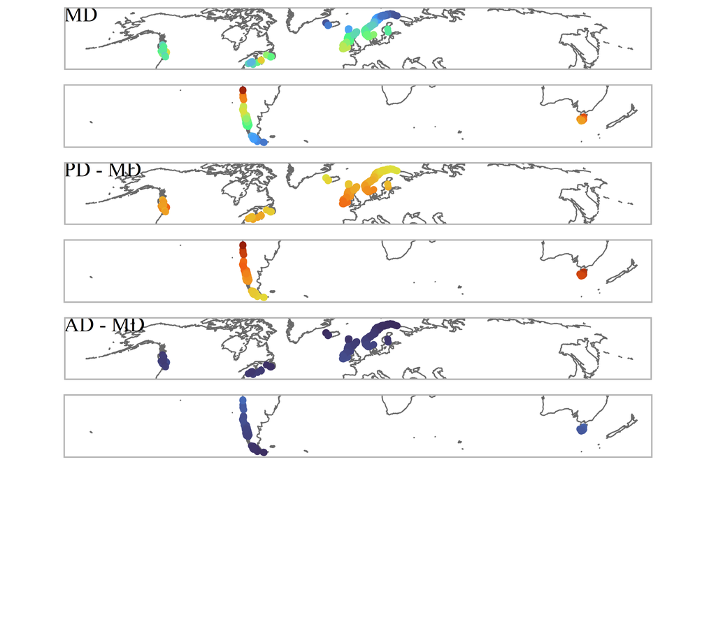

Figure 2: Map showing global distribution of total nitrogen and carbon loading for the MD feed at mean digestibility.

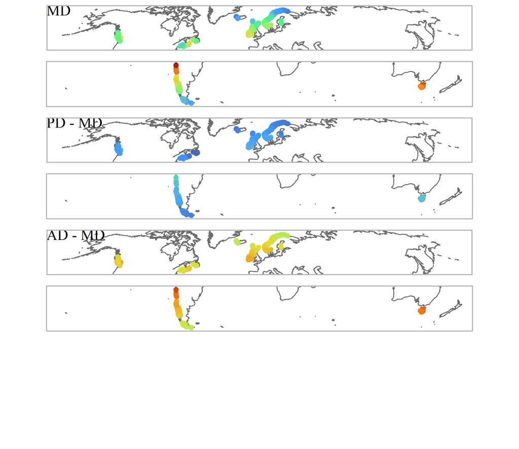

Figure 3: Map showing global distribution of total nitrogen and carbon loading for the MD feed at mean digestibility.

```r
border <- element_rect(colour = "grey70", fill = NA, linewidth = 1)

plot_grid(
  p_MD_C_north + theme(panel.border = border),
  p_MD_C_south + theme(panel.border = border),
  p_PD_C_north + theme(panel.border = border),
  p_PD_C_south + theme(panel.border = border),
  p_AD_C_north + theme(panel.border = border),
  p_AD_C_south + theme(panel.border = border),
  nrow = 8, rel_heights = c(1, 1.01, 1, 1.01, 1, 1.01, 1, 1.01)
)

plot_grid(
  p_MD_N_north + theme(panel.border = border),
  p_MD_N_south + theme(panel.border = border),
  p_PD_N_north + theme(panel.border = border),
  p_PD_N_south + theme(panel.border = border),
  p_AD_N_north + theme(panel.border = border),
  p_AD_N_south + theme(panel.border = border),
  nrow = 8, rel_heights = c(1, 1.01, 1, 1.01, 1, 1.01, 1, 1.01)
)
```

**Extract and display colour bar legends for global nutrient loading maps**

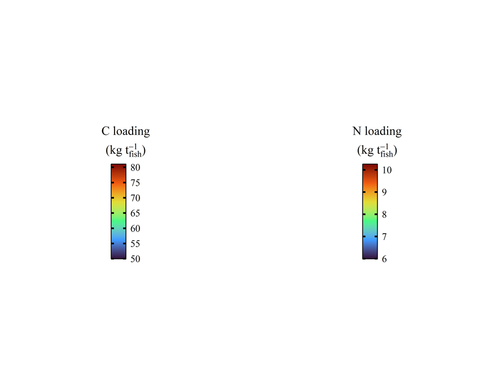

Figure 4: Colour bar legends for global C and N loading maps (top: MD absolute loading; bottom: PD and AD difference from MD).

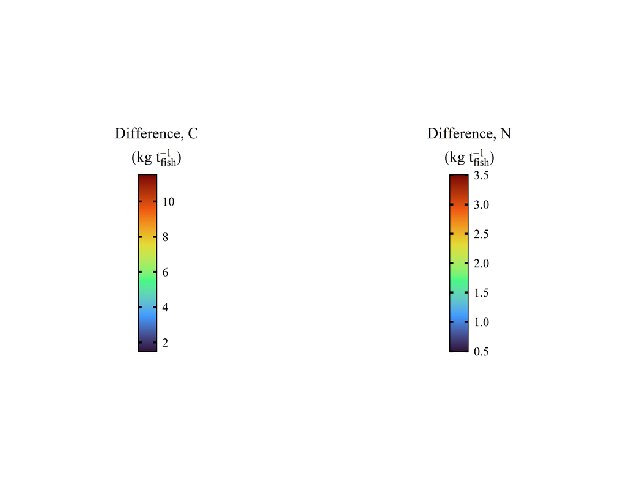

Figure 5: Colour bar legends for global C and N loading maps (top: MD absolute loading; bottom: PD and AD difference from MD).

```r
plot_grid(
  ggpubr::get_legend(p_MD_C_north + theme(legend.position = "right")),
  ggpubr::get_legend(p_MD_N_north + theme(legend.position = "right")),
  ncol = 2
)
plot_grid(
  ggpubr::get_legend(p_PD_C_north + theme(legend.position = "right")),
  ggpubr::get_legend(p_PD_N_north + theme(legend.position = "right")),
  ncol = 2
)
```

## 3.3 Latitudinal/temperature loading of C and N

**Smooth plot C and N loading vs temperature**

```r
plt_data <- rbind(farm_ends_carbon, farm_ends_nitrogen) %>%
  left_join(farm_locs, by = join_by(farm_ID)) %>%
  select(feed, nutrient, mean_value_perbiom, feed_level, mean_temp) %>%
  mutate(
    nutrient = factor(nutrient,
      levels = c("C", "N"),
      labels = c("Carbon", "Nitrogen")),
    feed_level = factor(feed_level,
      levels = c("min", "mean", "max"),
      labels = c("Minimum", "Mean", "Maximum"))
    )

nutrient_labels <- plt_data %>%
  distinct(nutrient) %>%
  mutate(label = as.character(nutrient))
```

**Smooth plot C and N loading vs temperature**

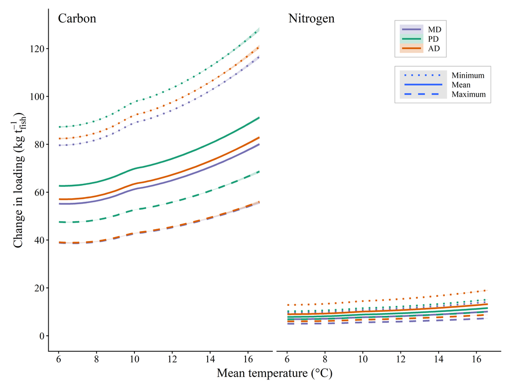

Figure 6: Change in C and N loading with farm mean temperature (fitted)

```r
p1 <- plt_data %>%
  ggplot(aes(
    x = mean_temp,
    y = drop_units(mean_value_perbiom),
    colour = feed,
    fill = feed,
    linetype = feed_level
  )) +
  geom_smooth(method = "loess", se = TRUE, alpha = 0.25, show.legend = c(fill = FALSE, colour = TRUE, linetype = TRUE)) +
  scale_colour_manual(values = feed_pal) +
  scale_fill_manual(values = feed_pal) +
  scale_y_continuous(breaks = seq(0, 150, 20), limits = c(0, 130)) +
  scale_x_continuous(breaks = seq(0, 20, 2), limits = c(6, 16.75)) +
  scale_linetype_manual(values = c("Mean" = "solid", "Maximum" = "dashed", "Minimum" = "dotted")) +
  facet_wrap(~nutrient, ncol = 2) +
  prettyplot_600() +
  labs(
    x = expression("Mean temperature ("*degree*"C)"),
    y = expression("Change in loading (kg"~t[fish]^{-1}*")")
  ) +
  geom_text(
    data        = nutrient_labels,
    aes(x = -Inf, y = Inf, label = label),
    hjust       = -0.25, vjust = 1.5,
    size        = 5.5, family = "serif",
    inherit.aes = FALSE
  ) +
  theme(strip.background = element_blank(), strip.text = element_blank())

legend_grob <- ggpubr::get_legend(
  p1 +
    guides(
      colour = guide_legend(
      ncol = 1,
      keywidth = unit(1, "cm")
    ),
      linetype = guide_legend(
      ncol = 1,
      keywidth = unit(2, "cm")
    )) +
    theme(
      legend.position = "right",
      legend.background = element_rect(fill = "white", colour = "grey70", linewidth = 0.3),
      legend.margin     = margin(5, 6, 5, 6),
      legend.key.size   = unit(0.4, "cm"),
      legend.text       = element_text(size = 10),
      legend.title      = element_blank()
    )
)

p1 + inset_element(
  legend_grob,
  left   = 0.80, right  = 0.95,  # x start, x end (fraction of plot width)
  bottom = 0.80, top    = 0.90,   # y start, y end
  align_to = "full"  # relative to full plot, not just panel area
)
```

**Plot change in C and N loading vs absolute latitude when switching from MD to PD or AD feed**

```r
plt_data <- rbind(farm_ends_carbon, farm_ends_nitrogen) %>%
  # filter(feed_level == "mean") %>%
  left_join(farm_locs, by = join_by(farm_ID)) %>%
  # mutate(latitute = st_coordinates(geometry)[, 2]) %>%
  select(farm_ID, feed, nutrient, mean_value_perbiom, feed_level, country, mean_temp) %>%
  pivot_wider(names_from = feed, values_from = mean_value_perbiom) %>%
  mutate(
    MD_PD_shift = PD - MD,
    MD_AD_shift = AD - MD
  ) %>%
  select(-contains("biomar")) %>%
  pivot_longer(
    cols = contains("shift"),
    names_to = "shift_to",
    values_to = "change_mean_perbiomass"
  ) %>%
  mutate(
    shift_to = factor(shift_to,
      levels = c("MD_PD_shift", "MD_AD_shift"),
      labels = c("PD", "AD")),
    nutrient = factor(nutrient,
      levels = c("C", "N"),
      labels = c("Carbon", "Nitrogen")),
    feed_level = factor(feed_level,
      levels = c("min", "mean", "max"),
      labels = c("Minimum", "Mean", "Maximum"))
    )

nutrient_labels <- plt_data %>%
  distinct(nutrient) %>%
  mutate(label = as.character(nutrient))
```

**Plot change in C and N loading vs temperature when switching from MD to PD or AD feed**

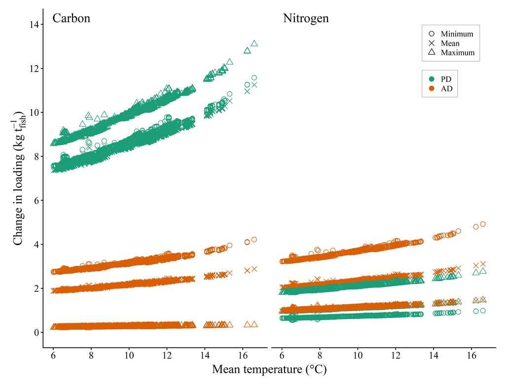

Figure 7: Change in nutrient loading when changing from MD to PD (green) or from MD to AD (orange) at all farm locations globally.

```r
p1 <- plt_data %>%
  ggplot(aes(
    x = mean_temp,
    y = drop_units(change_mean_perbiomass),
    colour = shift_to,
    shape = feed_level
  )) +
  geom_point(size = 2.5) +
  scale_colour_manual(values = feed_pal) +
  scale_y_continuous(breaks = seq(0, 14, 2), limits = c(0,14)) +
  scale_x_continuous(breaks = seq(0, 20, 2), limits = c(6, 16.75)) +
  scale_shape_manual(values = c(21, 4, 24)) +
  facet_wrap(~nutrient, ncol = 2) +
  prettyplot_600() +
  labs(
    x = expression("Mean temperature ("*degree*"C)"),
    y = expression("Change in loading (kg"~t[fish]^{-1}*")")
  ) +
  geom_text(
    data        = nutrient_labels,
    aes(x = -Inf, y = Inf, label = label),
    hjust       = -0.25, vjust = 1.5,
    size        = 5.5, family = "serif",
    inherit.aes = FALSE
  ) +
  theme(strip.background = element_blank(), strip.text = element_blank())

legend_grob <- ggpubr::get_legend(
  p1 +
    guides(colour = guide_legend(ncol = 1)) +
    theme(
      legend.position = "right",
      legend.background = element_rect(fill = "white", colour = "grey70", linewidth = 0.3),
      legend.margin     = margin(5, 6, 5, 6),
      legend.key.size   = unit(0.4, "cm"),
      legend.text       = element_text(size = 10),
      legend.title      = element_blank()
    )
)

p1 + inset_element(
  legend_grob,
  left   = 0.85, right  = 0.95,  # x start, x end (fraction of plot width)
  bottom = 0.80, top    = 0.90,   # y start, y end
  align_to = "full"  # relative to full plot, not just panel area
)
```

# 4 Shifts in temperature/latitude

**Show change in total carbon loading with temperature**

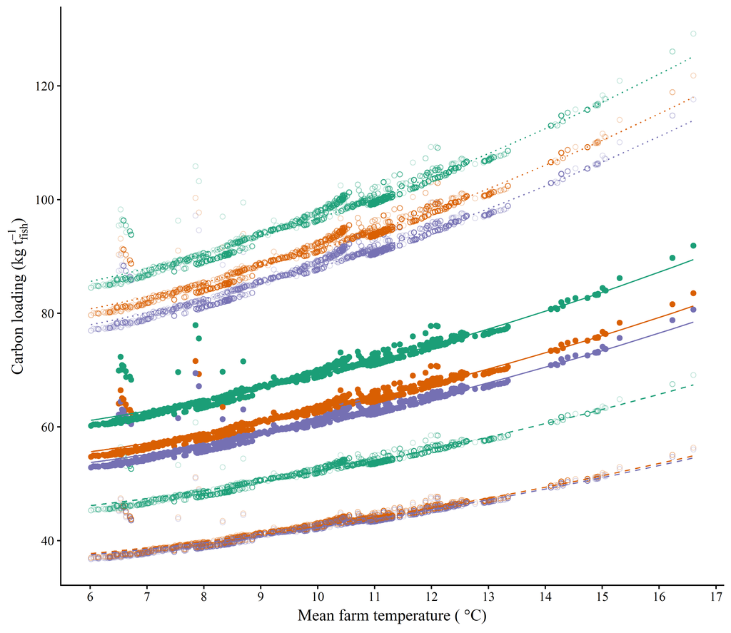

Figure 8: Total kg C t fish-1 with mean farm temperature.

```r
combined_df_C <- farm_ends_carbon_2 %>%
  mutate(mean_value_perbiom = mean_value_perbiom %>% set_units("g g_fish-1") %>% set_units("kg t_fish-1") %>% drop_units()) %>%
  left_join(coefs_carbon, by = c("feed", "feed_level" = "digest_level")) %>%
  mutate(fitted = a * mean_temp^b + c)

p_combined_df_C <- combined_df_C %>%
  ggplot(aes(
    x = mean_temp,
    colour = feed,
    shape = feed_level,
    alpha = feed_level,
    linetype = feed_level
  )) +
  geom_point(aes(y = mean_value_perbiom)) +
  geom_line(aes(y = fitted), alpha = 1) +
  scale_x_continuous(breaks = seq(2, 17, 1)) +
  scale_y_continuous(breaks = seq(0, 150, 20)) +
  scale_shape_manual(values = c("mean" = 19, "min" = 1, "max" = 1)) +
  scale_alpha_manual(values = c("mean" = 1, "min" = 0.25, "max" = 0.25)) +
  scale_linetype_manual(values = c(
    "mean" = "solid",
    "min" = "dotted", # "dashed",
    "max" = "dashed" # "dashed"
  )) +
  scale_colour_manual(values = feed_pal) +
  labs(
    x = expression("Mean farm temperature ("~degree*"C)"),
    y = expression("Carbon loading (kg"~t[fish]^{-1}*")")
  ) +
  prettyplot()

p_combined_df_C
```

**Show change in total nitrogen loading with temperature**

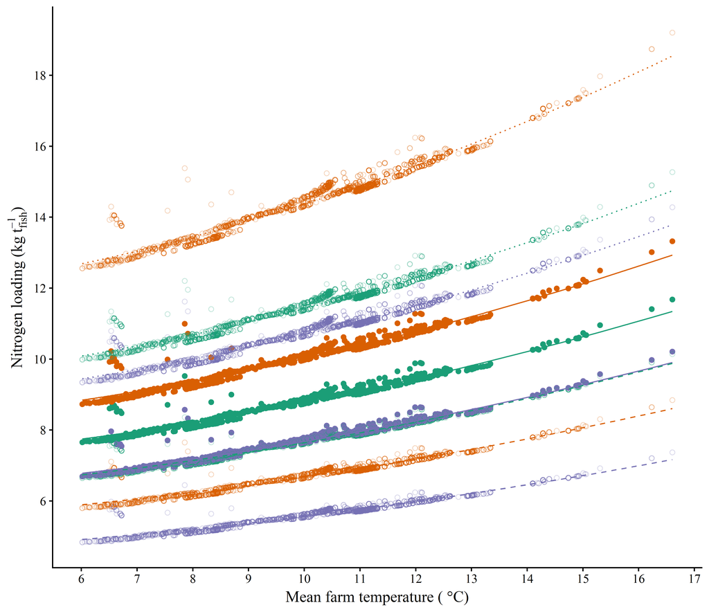

Figure 9: Total kg N t fish-1 with mean farm temperature.

```r
combined_df_N <- farm_ends_nitrogen_2 %>%
  mutate(mean_value_perbiom = mean_value_perbiom %>% set_units("g g_fish-1") %>% set_units("kg t_fish-1") %>% drop_units()) %>%
  left_join(coefs_nitrogen, by = c("feed", "feed_level" = "digest_level")) %>%
  mutate(fitted = a * mean_temp^b + c)

p_combined_df_N <- combined_df_N %>%
  ggplot(aes(
    x = mean_temp,
    colour = feed,
    shape = feed_level,
    alpha = feed_level,
    linetype = feed_level
  )) +
  geom_point(aes(y = mean_value_perbiom)) +
  geom_line(aes(y = fitted), alpha = 1) +
  scale_x_continuous(breaks = seq(2, 17, 1)) +
  scale_y_continuous(breaks = seq(0, 25, 2)) +
  scale_shape_manual(values = c("mean" = 19, "min" = 1, "max" = 1)) +
  scale_alpha_manual(values = c("mean" = 1, "min" = 0.25, "max" = 0.25)) +
  scale_linetype_manual(values = c(
    "mean" = "solid",
    "min" = "dotted", # "dashed",
    "max" = "dashed" # "dashed"
  )) +
  scale_colour_manual(values = feed_pal) +
  labs(
    x = expression("Mean farm temperature ("~degree*"C)"),
    y = expression("Nitrogen loading (kg"~t[fish]^{-1}*")")
  ) +
  prettyplot()

p_combined_df_N
```

**Show change in total carbon AND nitrogen loading with temperature**

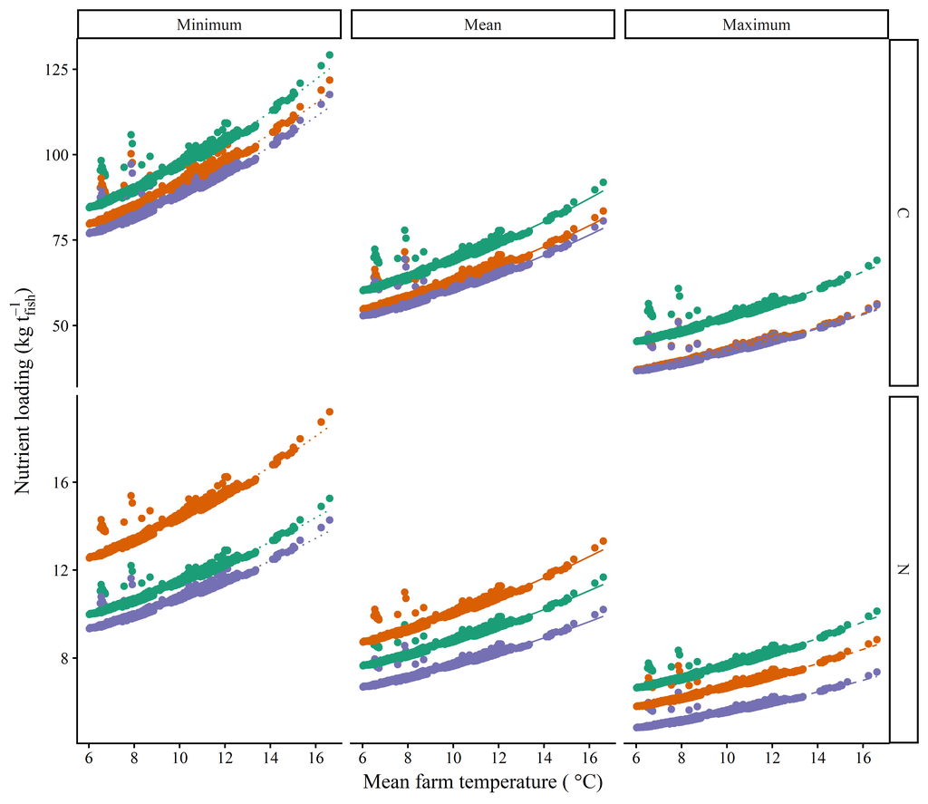

```r
combined_df_CN <- rbind(
    combined_df_C %>% mutate(nutrient = as.factor("C")),
    combined_df_N %>% mutate(nutrient = as.factor("N"))
  )

p_combined_df_CN <- combined_df_CN %>%
  mutate(feed_level = factor(feed_level, levels = c("min", "mean", "max"), labels = c("Minimum", "Mean", "Maximum"))) %>%
  ggplot(aes(
    x = mean_temp,
    colour = feed,
    # shape = feed_level,
    # alpha = feed_level,
    linetype = feed_level
  )) +
  geom_point(aes(y = mean_value_perbiom)) +
  geom_line(aes(y = fitted), alpha = 1) +
  scale_x_continuous(breaks = seq(2, 17, 2)) +
  # scale_y_continuous(breaks = seq(0, 25, 2)) +
  # scale_shape_manual(values = c("mean" = 19, "min" = 1, "max" = 1)) +
  # scale_alpha_manual(values = c("Mean" = 1, "Minimum" = 0.25, "Maximum" = 0.25)) +
  scale_linetype_manual(values = c(
    "Mean" = "solid",
    "Minimum" = "dotted", # "dashed",
    "Maximum" = "dashed" # "dashed"
  )) +
  scale_colour_manual(values = feed_pal) +
  labs(
    x = expression("Mean farm temperature ("~degree*"C)"),
    y = expression("Nutrient loading (kg"~t[fish]^{-1}*")")
  ) +
  facet_grid(cols = vars(feed_level), rows = vars(nutrient), scales = "free") +
  prettyplot()

p_combined_df_CN
```

# 5 Supplementary figures

## 5.1 Harvest sizes

**Plot distribution of individual harvest weights across farms**

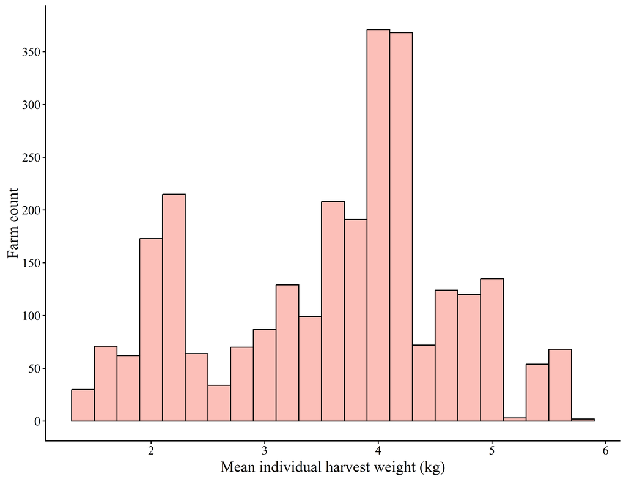

```r
harvest_size <- file.path(gendata_path, "harvest_sizes", "farm_harvest_sizes.qs") %>%
  qread()

harvest_size %>%
  ggplot(aes(x = weight/1000)) +
  geom_histogram(binwidth = 0.2, colour = "black", fill = "salmon", alpha = 0.5) +
  scale_y_continuous(breaks = seq(0, 350, 50), limits = c(0, 375)) +
  prettyplot_600() +
  labs(x = "Mean individual harvest weight (kg)", y = "Farm count")
```

## 5.2 Daily values

**Load and summarise daily C and N loading by country**

```r
farm_runs <- map2_dfr(
  c(file.path(output_path, "model_run_outputs", "farm_runs_total_carbon.qs"),
    file.path(output_path, "model_run_outputs", "farm_runs_total_nitrogen.qs")),
  c("C", "N"),
  function(fnm, nutr) {
    fnm %>%
      qread() %>%
      clean_up() %>%
      filter(feed == "MD" & feed_level == "mean") %>%
      mutate(nutrient = as.factor(nutr))
    }
  ) %>%
  left_join(farm_locs, by = join_by(farm_ID))

# How many farms per country? 10 seems like enough
farm_runs <- farm_runs %>%
  group_by(country, prod_t, nutrient) %>%
  reframe(
    n = n(),
    mean_value_perbiom = mean(mean_value_perbiom),
    sd_per_biom = sqrt(mean(sd_per_biom^2))
  )
```

**Plot daily C loading over the production cycle by country**

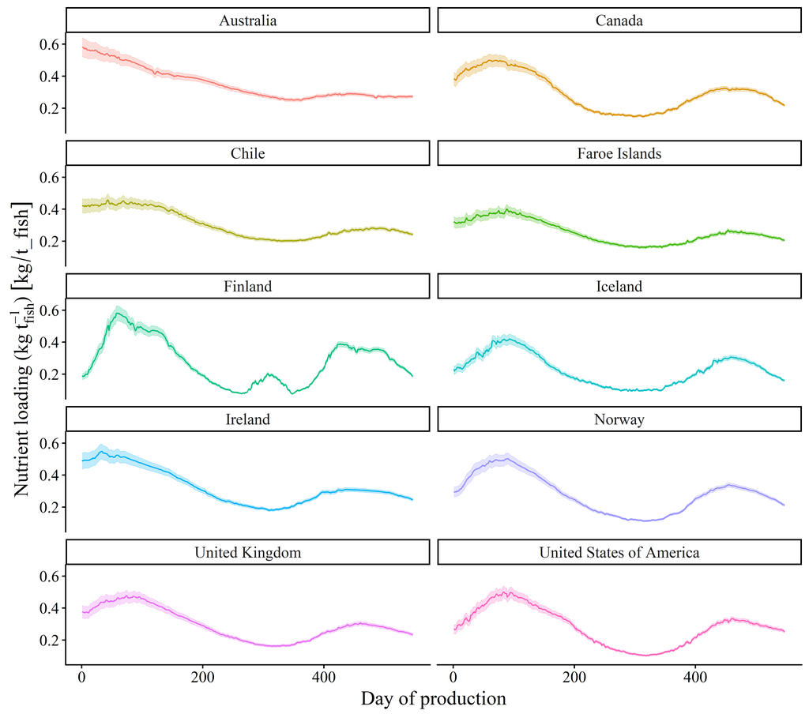

Figure 12: Daily carbon loading over the production cycle for the marine-dominant feed at mean digestibility, summarised by country.

```r
farm_runs %>%
  filter(nutrient == "C") %>%
  ggplot(aes(
    x = prod_t,
    y = mean_value_perbiom,
    ymin = mean_value_perbiom - sd_per_biom,
    ymax = mean_value_perbiom + sd_per_biom,
    colour = country,
    fill = country
  )) +
  geom_line(linewdith = 0.75) +
  geom_ribbon(linewidth = 0.1, alpha = 0.25) +
  facet_wrap(~country, ncol = 2) +
  prettyplot_600() +
  labs(
    x = "Day of production",
    y = expression("Nutrient loading (kg"~t[fish]^{-1}*")")
)
```

## 5.3 Model sensitivity

**Plot parameter sensitivity for individual weight and total excreted nutrients**

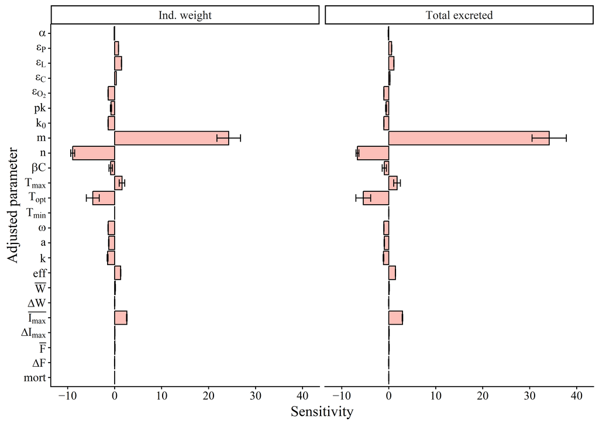

Figure 13: Parameter sensitivity for individual weight and total excreted nutrient outputs.

```r
sens <- file.path(output_sens_data_path, "sens_all.qs") %>%
  qread()

param_names <- tibble::tribble(
  ~name,        ~lab,
  "alpha",      bquote(alpha),
  "epsprot",    bquote(epsilon["P"]),
  "epslip",     bquote(epsilon["L"]),
  "epscarb",    bquote(epsilon["C"]),
  "epsO2",      bquote(epsilon["O"[2]]),
  "pk",         bquote("pk"),
  "k0",         bquote("k"[0]),
  "m",          bquote("m"),
  "n",          bquote("n"),
  "betac",      bquote(beta*"C"),
  "Tma",        bquote("T"["max"]),
  "Toa",        bquote("T"["opt"]),
  "Taa",        bquote("T"["min"]),
  "omega",      bquote(omega),
  "a",          bquote("a"),
  "k",          bquote("k"),
  "eff",        bquote("eff"),
  "meanW",      bquote(bar("W")),
  "deltaW",     bquote(Delta*"W"),
  "meanImax",   bquote(bar("I"["max"])),
  "deltaImax",  bquote(Delta*"I"["max"]),
  "overFmean",  bquote(bar("F")),
  "overFdelta", bquote(Delta*"F"),
  "mortmyt",    bquote("mort")
)

sens_x_labels <- c(paste0('\u2212', '10'), '0', '10', '20', '30', '40')

sens %>%
  filter(measure %in% c("weight_stat", "total_excr_stat") & adj_param != "nruns") %>%
  mutate(
    measure = factor(measure,
      levels = c("weight_stat", "total_excr_stat"),
      labels = c("Ind. weight", "Total excreted")
    )) %>%
  ggplot(aes(x = adj_param, y = mean_sens, ymin = mean_sens-sd_sens, ymax = mean_sens+sd_sens)) +
  geom_col(colour = "black", fill = "salmon", alpha = 0.5) +
  geom_errorbar(width = 0.5) +
  coord_flip() +
  scale_x_discrete(limits = rev(param_names$name), labels = rev(param_names$lab)) +
  scale_y_continuous(breaks = seq(-10, 40, 10), labels = sens_x_labels, limits = c(-11, 41)) +
  facet_wrap(~measure) +
  prettyplot_600() +
  labs(x = "Adjusted parameter", y = "Sensitivity")
```

← Previous: Data analysis

Next: Figures for manuscript →